# ECtHR News Classifier

model selection notes

J. M. Reis

2020-07-24

# 1 Intro

Training a classifier for identifying whether a (machine-translated) news articles is about a specific ecthr in our dataset, that is, for each ecthr ruling/news artice, identify whether the latter is about the former.

Load the packages.

```r
packs <- c("knitr", "rmdformats", "tidymodels", "textrecipes", "tidyverse", "themis", "ranger", "glmnet")
for (pack in packs){

  if (!pack %in% installed.packages()[,1]) {

    install.packages(pack)
    library(pack, character.only = TRUE)

  } else {

    library(pack, character.only = TRUE)

  }

}
```

# 2 Relevant features

Load the model dataset…

```r
## load the latest model dataset
# keep features plus c
model_data <- read_csv("../../data/model_data.csv.gz") %>%
  mutate(model_id = paste(case_id, article_id, sep = "_"),
         ecthr_label = as_factor(ecthr_label)) %>%
  select(ecthr_label, text, article_nchar, date_distance, cosine_similarity_tf, jaccard_distance, lang_og = source_lang_alpha2, contains("ner"), country_match_ratio, model_id) %>%
  drop_na()
glimpse(model_data)
```

```
Rows: 3,967
Columns: 27
$ ecthr_label          <fct> 0, 0, 0, 0, 0, 0, 0, 0, 0, 0, 0, 0, 0, 0, 1, 0, …
$ text                 <chr> "Lawyers Union of Romania organized a national s…
$ article_nchar        <dbl> 1433, 2546, 1996, 755, 2808, 2742, 1960, 1132, 1…
$ date_distance        <dbl> 5, -7, -10, -10, 7, 6, -2, -4, -6, -8, -8, 5, 5,…
$ cosine_similarity_tf <dbl> 0.016075962, 0.020864918, 0.029814285, 0.0519732…
$ jaccard_distance     <dbl> 0.0013346275, 0.0035679533, 0.0038415366, 0.0020…
$ lang_og              <chr> "ro", "ro", "ro", "ro", "ro", "ro", "ro", "ro", …
$ ner_date             <dbl> 0.00418410, 0.00000000, 0.00000000, 0.00000000, …
$ ner_gpe              <dbl> 0.000000000, 0.000000000, 0.000000000, 0.0000000…
$ ner_law              <dbl> 0, 0, 0, 0, 0, 0, 0, 0, 0, 0, 0, 0, 0, 0, 0, 0, …
$ ner_ordinal          <dbl> 0.0041841, 0.0000000, 0.0000000, 0.0000000, 0.00…
$ ner_org              <dbl> 0.000000000, 0.006666667, 0.000000000, 0.0000000…
$ ner_person           <dbl> 0.00000000, 0.00000000, 0.02000000, 0.00000000, …
$ ner_cardinal         <dbl> 0.000000000, 0.006666667, 0.020000000, 0.0243902…
$ ner_loc              <dbl> 0.000000000, 0.006666667, 0.000000000, 0.0000000…
$ ner_norp             <dbl> 0.000000000, 0.000000000, 0.000000000, 0.0000000…
$ ner_money            <dbl> 0, 0, 0, 0, 0, 0, 0, 0, 0, 0, 0, 0, 0, 0, 0, 0, …
$ ner_quantity         <dbl> 0, 0, 0, 0, 0, 0, 0, 0, 0, 0, 0, 0, 0, 0, 0, 0, …
$ ner_time             <dbl> 0.000000000, 0.000000000, 0.000000000, 0.0000000…
$ ner_work             <dbl> 0, 0, 0, 0, 0, 0, 0, 0, 0, 0, 0, 0, 0, 0, 0, 0, …
$ ner_product          <dbl> 0, 0, 0, 0, 0, 0, 0, 0, 0, 0, 0, 0, 0, 0, 0, 0, …
$ ner_event            <dbl> 0, 0, 0, 0, 0, 0, 0, 0, 0, 0, 0, 0, 0, 0, 0, 0, …
$ ner_fac              <dbl> 0.00000000, 0.00000000, 0.00000000, 0.00000000, …
$ ner_percent          <dbl> 0.000000000, 0.000000000, 0.000000000, 0.0000000…
$ ner_language         <dbl> 0, 0, 0, 0, 0, 0, 0, 0, 0, 0, 0, 0, 0, 0, 0, 0, …
$ country_match_ratio  <dbl> 1.0000000, 0.8000000, 0.5714286, 0.0000000, 0.13…
$ model_id             <chr> "32925/96_Romania_ADEVARUL_2002-07-04_news-socie…
```

## 2.1 Ngrams represented as TF or TF-IDF vectors

These features will be generated below…

1. We took each article and translated it to english using google translate [(unoffical) api](https://pypi.org/project/googletrans/).
2. Next, we tokenize the text into ngrams from 1-4.
3. As for pre-processing, will keep it simple. Only remove stop-words and punctuation. Practices such as stemming or lemmatization might be problematic in our context since, for example, verb conjugations are expected to be relatively relavant for identifying whether, say, the ruling mentioned is the actual one or parallel one close by.

## 2.2 Ruling-article document similarity (original language or english translations)

The main idea is that the two documents, ruling and article, being close in their language should be indicative of whether the article covers it. String comparisons where done by comparing both as *document term matrices* where each is represented as a term-frequency normalized by document lenght (unique words) vector.

TF-IDF seemed problematic in this instance given that the most relevant words were used as key-words, and thus would be probably excessively deflated.

1. We downloaded the rulings as well as ruling communication notices [e.g.](https://hudoc.echr.coe.int/fre?i=001-57619) in all language avaiable for each case.
2. The choice of relevant document was done according to the following steps:

   2.1 If ruling is available in the original language $\to$ string comparison with article in original language; when missing.

   2.2. If ruling is available in english $\to$ string comparison with machine translated version of the article.

   2.3. If ruling is available in french (the other official language) machine translate it to english $\to$ string comparison with machine translated version of the article.

   2.4. If there is any ruling in any language available, take it and machine translate it $\to$ string comparison with machine translated version of the article.

   2.5. Repeat the steps above for communication notices. We found ruling docs for all cases in our dataset.
3. For each dyad, we tokenized them using [a language specific tokenizers](https://stanfordnlp.github.io/stanza/) and extract morphological information for each word (*idem*). We first filtered the docs by pos-tags[^1]. Removed stop-words using a [language specific corpus](https://github.com/stopwords-iso/stopwords-iso). Tokenized them into 1-5 ngrams and computed their corpus length normalized term frequencies.
4. As for comparison, I first computed their [cosine similarity](https://www.sciencedirect.com/topics/computer-science/cosine-similarity) and then the [jaccard distance](https://en.wikipedia.org/wiki/Jaccard_index) between the tokens in each vector.

```r
model_data %>% group_by(ecthr_label) %>% summarise(mean_cos = IQR(cosine_similarity_tf), mean_jac = IQR(jaccard_distance))
```

```
# A tibble: 2 x 3
  ecthr_label mean_cos mean_jac
  <fct>          <dbl>    <dbl>
1 0             0.0512  0.00349
2 1             0.144   0.00598
```

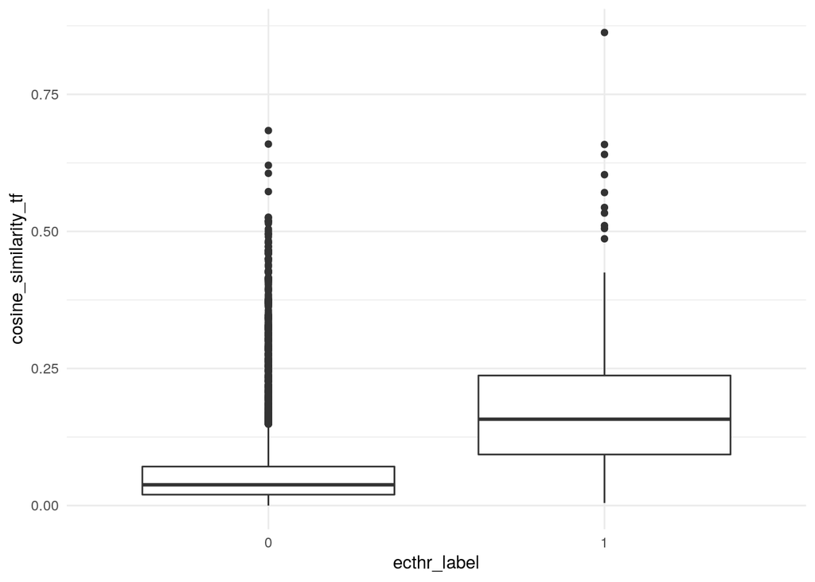

```r
model_data %>%
  ggplot(aes(x = ecthr_label, cosine_similarity_tf)) +
  geom_boxplot() +
  theme_minimal()
```

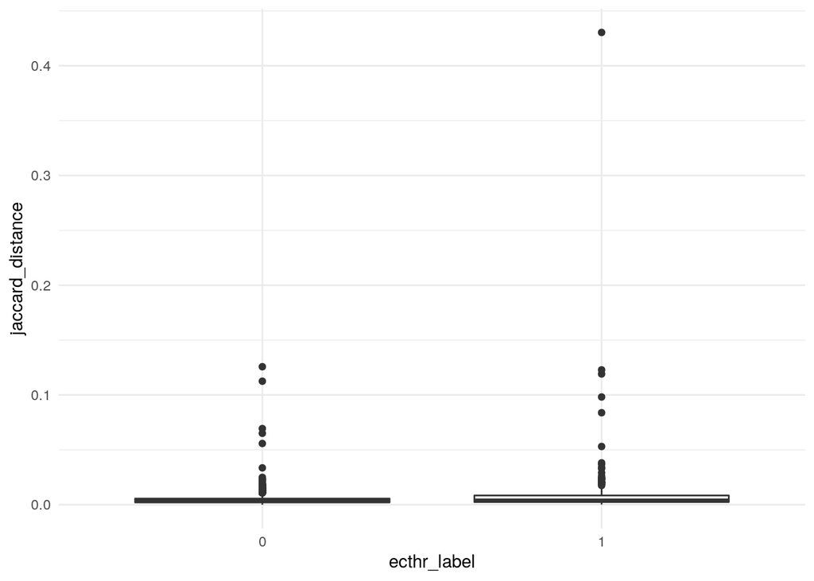

```r
model_data %>%
  ggplot(aes(x = ecthr_label, jaccard_distance)) +
  geom_boxplot() +
  theme_minimal()
```

## 2.3 NER ratios

We further extracted recognized the named entities from the articles using [spacy](https://spacy.io/), counted their frequencies and normalized them by dividing the counts by the number of words in the text.

```r
model_data %>%
  select(contains("ner")) %>%
  glimpse()
```

```
Rows: 3,967
Columns: 18
$ ner_date     <dbl> 0.00418410, 0.00000000, 0.00000000, 0.00000000, 0.000000…
$ ner_gpe      <dbl> 0.000000000, 0.000000000, 0.000000000, 0.000000000, 0.00…
$ ner_law      <dbl> 0, 0, 0, 0, 0, 0, 0, 0, 0, 0, 0, 0, 0, 0, 0, 0, 0, 0, 0,…
$ ner_ordinal  <dbl> 0.0041841, 0.0000000, 0.0000000, 0.0000000, 0.0000000, 0…
$ ner_org      <dbl> 0.000000000, 0.006666667, 0.000000000, 0.000000000, 0.00…
$ ner_person   <dbl> 0.00000000, 0.00000000, 0.02000000, 0.00000000, 0.000000…
$ ner_cardinal <dbl> 0.000000000, 0.006666667, 0.020000000, 0.024390244, 0.00…
$ ner_loc      <dbl> 0.000000000, 0.006666667, 0.000000000, 0.000000000, 0.00…
$ ner_norp     <dbl> 0.000000000, 0.000000000, 0.000000000, 0.000000000, 0.00…
$ ner_money    <dbl> 0, 0, 0, 0, 0, 0, 0, 0, 0, 0, 0, 0, 0, 0, 0, 0, 0, 0, 0,…
$ ner_quantity <dbl> 0, 0, 0, 0, 0, 0, 0, 0, 0, 0, 0, 0, 0, 0, 0, 0, 0, 0, 0,…
$ ner_time     <dbl> 0.000000000, 0.000000000, 0.000000000, 0.000000000, 0.00…
$ ner_work     <dbl> 0, 0, 0, 0, 0, 0, 0, 0, 0, 0, 0, 0, 0, 0, 0, 0, 0, 0, 0,…
$ ner_product  <dbl> 0, 0, 0, 0, 0, 0, 0, 0, 0, 0, 0, 0, 0, 0, 0, 0, 0, 0, 0,…
$ ner_event    <dbl> 0, 0, 0, 0, 0, 0, 0, 0, 0, 0, 0, 0, 0, 0, 0, 0, 0, 0, 0,…
$ ner_fac      <dbl> 0.00000000, 0.00000000, 0.00000000, 0.00000000, 0.000000…
$ ner_percent  <dbl> 0.000000000, 0.000000000, 0.000000000, 0.000000000, 0.00…
$ ner_language <dbl> 0, 0, 0, 0, 0, 0, 0, 0, 0, 0, 0, 0, 0, 0, 0, 0, 0, 0, 0,…
```

## 2.4 country match ratio

Similarly, we extracted all mentions of countries using the above-mentioned algorithm. Next, we counted the number of country matches with the country which was party with the case and normalized these counts by dividing it from all the country mentions.

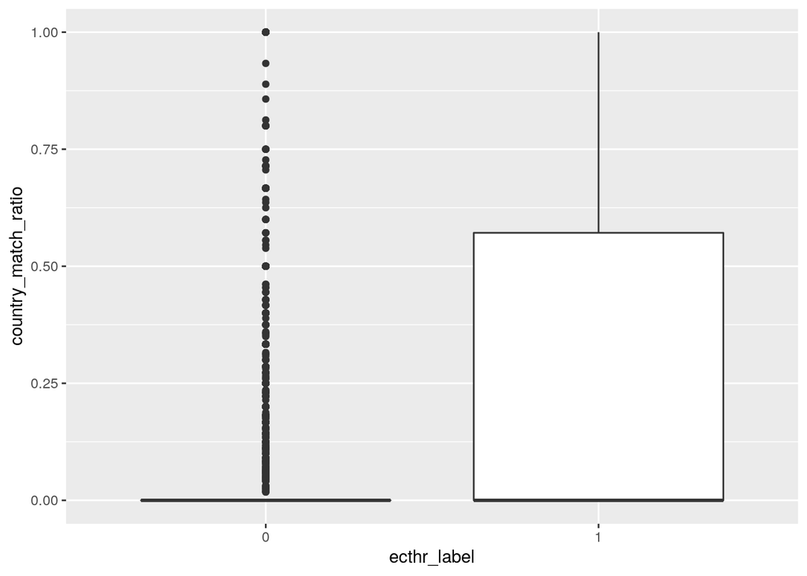

```r
model_data %>%
  ggplot(aes(ecthr_label, country_match_ratio)) +
  geom_boxplot()
```

## 2.5 Date distance

Took the difference in the number of days between the judgment date and the publication date for the article. Articles covering the ruling are expected to be more likely in the days leading to or following the ruling. Though on its own, its seems unlikely.

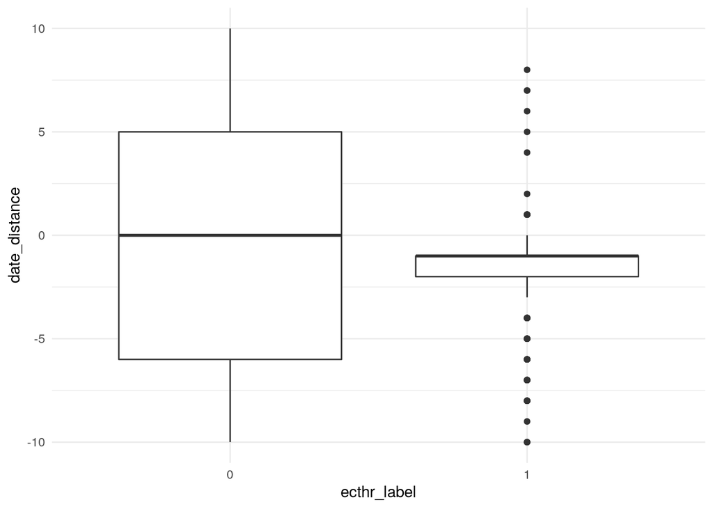

```r
model_data %>%
  ggplot(aes(x = ecthr_label, date_distance)) +
  geom_boxplot() +
  theme_minimal()
```

## 2.6 Number of characters in article

Standard feature. Length of an article might indicate topic given current agenda cycle, though it may go in any direction.

## 2.7 Source language

Language of the text before translation, `source_lang_alpha2` to capture language-related weaknesses in the machine translation and its consequences in the coding.

# 3 Modeling

## 3.1 Sampling

Split the data, 70% for training and the remaining for testing, stratified by article language.

```r
set.seed(1234)
the_split <- initial_split(model_data, strata = "lang_og", p = 0.70)
train_data <- training(the_split)
test_data <- testing(the_split)

train_data %>%
  group_by(ecthr_label) %>%
  summarise(n = n())
```

```
# A tibble: 2 x 2
  ecthr_label     n
  <fct>       <int>
1 0            2555
2 1             223
```

```r
test_data %>%
  group_by(ecthr_label) %>%
  summarise(n = n())
```

```
# A tibble: 2 x 2
  ecthr_label     n
  <fct>       <int>
1 0            1114
2 1              75
```

## 3.2 Pre-processing

We start with the pre-processing. For this I will resort to `recipes` from tidymodels. This allows me to generate a pre-processing workflow which can be used in both training and testing datasets. For all the text-related pre-processing I will use `textrecipes`, [details here](https://github.com/tidymodels/textrecipes).

While stemming and stop-words removal may not be optimal, they seem to be the best alternative for reducing the dimensions of the text features while loosing the least information. Models without these steps constantly crashed. For the same reason, I restricted the ngrams to 1-3.

Starting with the text. Will create three recipes.

1. tf_main:
- tf vectors (1-3 ngrams)
- no stopwords
- stemmed
- tf > 2
- main sampling
- number of character natural logged
- lang to dummies
- random sample

```r
tf_main <- recipe(ecthr_label ~ .,
                  data = train_data) %>%
  update_role(model_id, new_role = "id variable") %>%
  step_dummy(lang_og) %>%
  step_log(article_nchar) %>%
  step_tokenize(text, token = "ngrams", options = list(n = 3, n_min = 1)) %>%
  step_stem(text) %>%
  step_stopwords(text, keep = FALSE, stopword_source = "stopwords-iso") %>%
  step_tokenfilter(text, min_times = 2)  %>%
  step_tf(text)
## the recipe
tf_main
```

```
Data Recipe

Inputs:

        role #variables
 id variable          1
     outcome          1
   predictor         25

Operations:

Dummy variables from lang_og
Log transformation on article_nchar
Tokenization for text
Stemming for text
Stop word removal for text
Text filtering for text
Term frequency with text
```

2. tfidf_main:
- tf-idf vectors (1-3 ngrams)
- no stopwords
- stemmed
- tf > 2
- main sampling
- number of character natural logged
- lang to dummies
- random sample

```r
tfidf_main <- recipe(ecthr_label ~ .,
                  data = train_data) %>%
  update_role(model_id, new_role = "id variable") %>%
  step_dummy(lang_og) %>%
  step_log(article_nchar) %>%
  step_tokenize(text, token = "ngrams", options = list(n = 3, n_min = 1)) %>%
  step_stem(text) %>%
  step_stopwords(text, keep = FALSE, stopword_source = "stopwords-iso") %>%
  step_tokenfilter(text, min_times = 2)  %>%
  step_tfidf(text)

## the recipe
tfidf_main
```

```
Data Recipe

Inputs:

        role #variables
 id variable          1
     outcome          1
   predictor         25

Operations:

Dummy variables from lang_og
Log transformation on article_nchar
Tokenization for text
Stemming for text
Stop word removal for text
Text filtering for text
Term frequency-inverse document frequency with text
```

## 3.3 Bulding the models

The choice of models will be based on their (i) explainability (less black-box) and (ii) availability of implementation of cost-weights to compensate the class imbalance

### 3.3.1 Penalized logistic regression (LASSO)

First, we fit a logistic regression penalized with a LASSO (least absolute shrinkage and selection operator)[^3]] - adding a penalty term to the log likelihood function so as to shrink coefficients of the variables which contribute more to the error in te model to 0. Hence operating as feature selection. This should result in a more efficient model and less prone to overfitting.

This is particularly useful for us since we will be using text-features too. The selected penalty term will be chosen based on its ability to minimize out of sample prediction errors, namely via grid search of a vector of several penalty terms (lamda) and using bootstrap cross-validation.

#### 3.3.1.1 model

```r
### penalized logistic regression (lasso)
# penalty -> lambda; allowed to vary for hyperparameter tuning
# mixture = 1 for lasso regression
lasso_spec <- logistic_reg(penalty = tune(), mixture = 1) %>%
  set_mode("classification") %>%
  set_engine("glmnet")
```

#### 3.3.1.2 Hyperparameter grid and bootstrap samples

```r
# tuning grid, range of 100 penalty values
param_grid <- grid_regular(penalty(),
                           levels = 100)

# bootstraping for the parameter tunning. 10 bootstraps
set.seed(1234)
ecthr_boot <- bootstraps(train_data, times = 10, strata = "ecthr_label")
ecthr_boot
```

```
# Bootstrap sampling using stratification
# A tibble: 10 x 2
   splits            id
   <list>            <chr>
 1 <split [2.8K/1K]> Bootstrap01
 2 <split [2.8K/1K]> Bootstrap02
 3 <split [2.8K/1K]> Bootstrap03
 4 <split [2.8K/1K]> Bootstrap04
 5 <split [2.8K/1K]> Bootstrap05
 6 <split [2.8K/1K]> Bootstrap06
 7 <split [2.8K/1K]> Bootstrap07
 8 <split [2.8K/1K]> Bootstrap08
 9 <split [2.8K/1K]> Bootstrap09
10 <split [2.8K/1K]> Bootstrap10
```

#### 3.3.1.3 Prepare the workflow

We will add `step_normalize(all_predictors())`, i.e. normalize all predictors, as it is recommended

```r
## Prep the workflow
lasso_wf <- workflow() %>%
  add_recipe(
    tf_main %>%
      step_normalize(all_predictors(), -article_nchar) # since it is logged
    ) %>%
  add_model(lasso_spec)

lasso_wf
```

```
══ Workflow ═══════════════════════════════════════════════════════════════════════════════════════
Preprocessor: Recipe
Model: logistic_reg()

── Preprocessor ───────────────────────────────────────────────────────────────────────────────────
8 Recipe Steps

● step_dummy()
● step_log()
● step_tokenize()
● step_stem()
● step_stopwords()
● step_tokenfilter()
● step_tf()
● step_normalize()

── Model ──────────────────────────────────────────────────────────────────────────────────────────
Logistic Regression Model Specification (classification)

Main Arguments:
  penalty = tune()
  mixture = 1

Computational engine: glmnet
```

#### 3.3.1.4 Training and tunning the model

```r
### identify the best lambda via grid search
# parallelize
doParallel::registerDoParallel()
set.seed(1234)
lasso_grid <- tune_grid(
  lasso_wf,
  resamples = ecthr_boot,
  grid = param_grid,
  control = control_grid(verbose = FALSE, save_pred = TRUE),
  metrics = metric_set(accuracy, roc_auc, bal_accuracy, kap)
)


lasso_grid %>%
  collect_metrics()
```

```
# A tibble: 400 x 7
    penalty .metric      .estimator  mean     n std_err .config
      <dbl> <chr>        <chr>      <dbl> <int>   <dbl> <fct>
 1 1.00e-10 accuracy     binary     0.909    10 0.00364 Model001
 2 1.00e-10 bal_accuracy binary     0.661    10 0.0102  Model001
 3 1.00e-10 kap          binary     0.352    10 0.0177  Model001
 4 1.00e-10 roc_auc      binary     0.843    10 0.00341 Model001
 5 1.26e-10 accuracy     binary     0.909    10 0.00364 Model002
 6 1.26e-10 bal_accuracy binary     0.661    10 0.0102  Model002
 7 1.26e-10 kap          binary     0.352    10 0.0177  Model002
 8 1.26e-10 roc_auc      binary     0.843    10 0.00341 Model002
 9 1.59e-10 accuracy     binary     0.909    10 0.00364 Model003
10 1.59e-10 bal_accuracy binary     0.661    10 0.0102  Model003
# … with 390 more rows
```

#### 3.3.1.5 Select best model and finalize the workflow

```r
## check which lambda performed the best using imbalance robust metrics
lasso_grid
```

```
# Tuning results
# Bootstrap sampling using stratification
# A tibble: 10 x 5
   splits          id         .metrics         .notes        .predictions
   <list>          <chr>      <list>           <list>        <list>
 1 <split [2.8K/1… Bootstrap… <tibble [400 × … <tibble [0 ×… <tibble [103,600 ×…
 2 <split [2.8K/1… Bootstrap… <tibble [400 × … <tibble [0 ×… <tibble [104,900 ×…
 3 <split [2.8K/1… Bootstrap… <tibble [400 × … <tibble [1 ×… <tibble [104,600 ×…
 4 <split [2.8K/1… Bootstrap… <tibble [400 × … <tibble [0 ×… <tibble [101,400 ×…
 5 <split [2.8K/1… Bootstrap… <tibble [400 × … <tibble [0 ×… <tibble [101,700 ×…
 6 <split [2.8K/1… Bootstrap… <tibble [400 × … <tibble [1 ×… <tibble [102,800 ×…
 7 <split [2.8K/1… Bootstrap… <tibble [400 × … <tibble [1 ×… <tibble [101,000 ×…
 8 <split [2.8K/1… Bootstrap… <tibble [400 × … <tibble [1 ×… <tibble [104,300 ×…
 9 <split [2.8K/1… Bootstrap… <tibble [400 × … <tibble [0 ×… <tibble [101,800 ×…
10 <split [2.8K/1… Bootstrap… <tibble [400 × … <tibble [1 ×… <tibble [104,100 ×…
```

```r
# cohen's kappa
show_best(lasso_grid, metric = "kap")
```

```
# A tibble: 5 x 7
   penalty .metric .estimator  mean     n std_err .config
     <dbl> <chr>   <chr>      <dbl> <int>   <dbl> <fct>
1 2.85e- 5 kap     binary     0.353    10  0.0176 Model055
2 1.79e- 5 kap     binary     0.352    10  0.0178 Model053
3 2.26e- 5 kap     binary     0.352    10  0.0178 Model054
4 1.00e-10 kap     binary     0.352    10  0.0177 Model001
5 1.26e-10 kap     binary     0.352    10  0.0177 Model002
```

```r
# balanced accuracy (average of the sensitivity,TP, and of the specificity,TN)
show_best(lasso_grid, metric = "bal_accuracy")
```

```
# A tibble: 5 x 7
   penalty .metric      .estimator  mean     n std_err .config
     <dbl> <chr>        <chr>      <dbl> <int>   <dbl> <fct>
1 2.85e- 5 bal_accuracy binary     0.662    10  0.0101 Model055
2 1.79e- 5 bal_accuracy binary     0.661    10  0.0101 Model053
3 2.26e- 5 bal_accuracy binary     0.661    10  0.0101 Model054
4 1.00e-10 bal_accuracy binary     0.661    10  0.0102 Model001
5 1.26e-10 bal_accuracy binary     0.661    10  0.0102 Model002
```

```r
## pull the best model specification using cohen's kappa as the relevant metric
best_penalty <- select_best(lasso_grid, metric =  "kap")
## final workflow for the lasso logistic regression model
final_lasso <- finalize_workflow(
  lasso_wf,
  best_penalty
)
```

### 3.3.2 Random forests

Next, a random forests models following `ranger`’s implementation. First we will implement one attributing the same costs for all miss-classifications and later we will implement a cost sensitive one.

Not fitting…keeps crashing…

#### 3.3.2.1 Parameter tuning

Tunable hyperparameters[^4]: - The number of randomly drawn candidate variables out of which each split is selected when growing a tree (mtry). Lower values of mtry lead to less correlated trees which is good, however this might lead to decreases in average accuracy as the probability of not including a relevant variable increases. Traditionally, the default value proposed for balancing these concerns is $mtry=\sqrt{\#features}$. - Node size (min_n). The node size parameter specifies the minimum number of observations in a terminal node. Low values lead to trees with a larger depth and so more splits are performed until the terminal nodes.

[^1]: Namely, the following universal pos-tags were kept: “VERB”, “ADJ”, “ADP”, “ADV”, “DET”, “AUX”, “NOUN”, “NUM”, “PRON”, “PROPN”, “PART”; check https://universaldependencies.org/u/pos/
[^2]: [see](https://www.researchgate.net/publication/220705031_Cost-Sensitive_Learning_vs_Sampling_Which_is_Best_for_Handling_Unbalanced_Classes_with_Unequal_Error_Costs)
[^3]: using `glmnet`, [see](https://web.stanford.edu/~hastie/glmnet/glmnet_alpha.html)
[^4]: [see](https://arxiv.org/pdf/1804.03515.pdf)